# Group 10 - Assignment 1 Notebook

## Project Members:

- Sarath Gentela
- Vamshi Konduri
- Laxmi Sandumalla
- Brian Anderson

This notebook is a summary notebook for Assignment 01 which uses the *vegashotels*, *california-housing*, and *UCI Heart Disease* datasets these data sets can be found: [Vegas Hotels](https://archive.ics.uci.edu/ml/datasets/Las%2BVegas%2BStrip) [California Housing](https://www.kaggle.com/camnugent/california-housing-prices) [UCI Heart Disease](https://archive.ics.uci.edu/ml/datasets/heart+disease)

Current R notebook assumes that workspace directory is set to the root of the project folder and that all data files exist in a /data subdirectory folder

Students answers will generally be included in blockquote sections

Please run the following command for gmodels integration for CrossTable support. If gmodels is not installed please run

```r
install.packages("gmodels")
```

And now run to load the extension

```r
library(gmodels)
```

Also we would like to have the appropriate filepath prefix

```r
missing <- function(x){
  return(sum(colSums(is.na(x))))
}

filepath_prefix = paste(getwd(), "/data/", sep="")
print(filepath_prefix)
```

```
[1] "/Users/briananderson/r/aiml/modules/03/data/"
```

# Problem 1 - Vegas Hotels Dataset

*Explore the vegas hotel dataset*

**1 - Explore the overall structure of the dataset using `str()`. When you read the data, set `StringAsFactors=True` to let R convert String variables to factors.**

```r
filename = paste(filepath_prefix, "vegashotels-1.csv", sep="")
print(filename)
```

```
[1] "/Users/briananderson/r/aiml/modules/03/data/vegashotels-1.csv"
```

```r
data_frame = read.csv(filename,sep=";", stringsAsFactors=TRUE, header=TRUE, strip.white=TRUE)
str(data_frame)
```

```
'data.frame':   504 obs. of  20 variables:
 $ User.country     : Factor w/ 47 levels "Australia","Belgium",..: 47 47 47 45 4 4 45 47 18 4 ...
 $ Nr..reviews      : int  11 119 36 14 5 31 45 2 24 12 ...
 $ Nr..hotel.reviews: int  4 21 9 7 5 8 12 1 3 7 ...
 $ Helpful.votes    : int  13 75 25 14 2 27 46 4 8 11 ...
 $ Score            : int  5 3 5 4 4 3 4 4 4 3 ...
 $ Period.of.stay   : Factor w/ 4 levels "Dec-Feb","Jun-Aug",..: 1 1 3 3 3 3 3 3 3 3 ...
 $ Traveler.type    : Factor w/ 5 levels "Business","Couples",..: 4 1 3 4 5 2 2 3 4 3 ...
 $ Pool             : Factor w/ 2 levels "NO","YES": 1 1 1 1 1 1 1 1 1 1 ...
 $ Gym              : Factor w/ 2 levels "NO","YES": 2 2 2 2 2 2 2 2 2 2 ...
 $ Tennis.court     : Factor w/ 2 levels "NO","YES": 1 1 1 1 1 1 1 1 1 1 ...
 $ Spa              : Factor w/ 2 levels "NO","YES": 1 1 1 1 1 1 1 1 1 1 ...
 $ Casino           : Factor w/ 2 levels "NO","YES": 2 2 2 2 2 2 2 2 2 2 ...
 $ Free.internet    : Factor w/ 2 levels "NO","YES": 2 2 2 2 2 2 2 2 2 2 ...
 $ Hotel.name       : Factor w/ 21 levels "Bellagio Las Vegas",..: 3 3 3 3 3 3 3 3 3 3 ...
 $ Hotel.stars      : Factor w/ 5 levels "3","3,5","4",..: 1 1 1 1 1 1 1 1 1 1 ...
 $ Nr..rooms        : int  3773 3773 3773 3773 3773 3773 3773 3773 3773 3773 ...
 $ User.continent   : Factor w/ 6 levels "Africa","Asia",..: 4 4 4 3 4 4 3 4 2 4 ...
 $ Member.years     : int  9 3 2 6 7 2 4 0 3 5 ...
 $ Review.month     : Factor w/ 12 levels "April","August",..: 5 5 4 4 8 8 1 1 9 9 ...
 $ Review.weekday   : Factor w/ 7 levels "Friday","Monday",..: 5 1 3 1 6 6 1 6 3 6 ...
```

**2- Are there any missing values?**

```r
cat("The overall data-frame is missing : ",missing(data_frame), "values\n")
```

```
The overall data-frame is missing :  0 values
```

**3 - Draw a histogram of the score variables. Interpret the histogram**

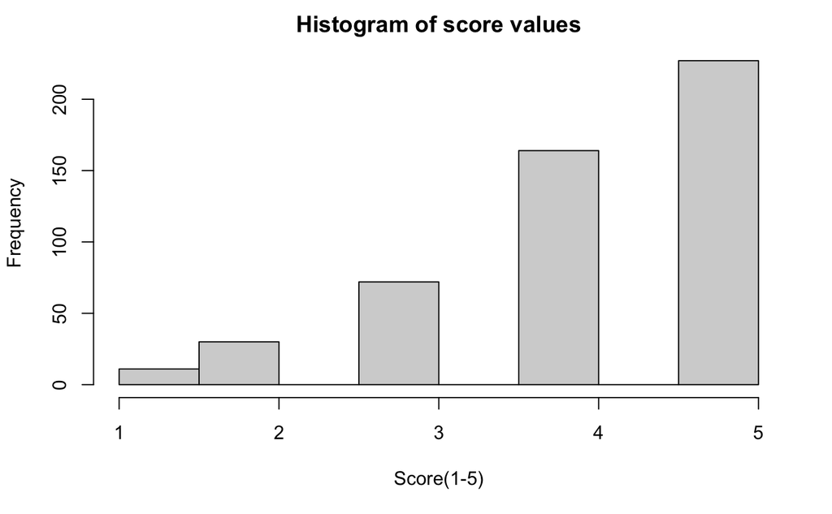

```r
hist(data_frame$Score, main="Histogram of score values", xlab="Score(1-5)")
```

**4 - Find the mode of score**

```r
score_table = table(as.vector(data_frame$Score))
mod = names(score_table)[score_table == max(score_table)]
cat("Mode of the scores is : ", mod, "\n")
```

```
Mode of the scores is :  5
```

**5 - Use the quantile function to get quantiles for score, what is the median of score**

```r
q_str = quantile(data_frame$Score, seq(from = 0, to = 1, by =0.25))
cat("Quantiles: ", q_str, "\n")
```

```
Quantiles:  1 4 4 5 5
```

```r
cat("Median: ", median(data_frame$Score), "\n")
```

```
Median:  4
```

**6 - Use the ifelse function pass in a factor variable sentiment of “positive” or “negative” take a summary of sentiment to make sure the frequencies of the categories are consistent with the values of score. e.g. positive sentimment should be equal to the frequency of 4 and 5 for Score**

```r
data_frame$sentiment = as.factor(ifelse(data_frame$Score >= 4, "positive", "negative"))
positive_scores = data_frame$Score[data_frame$Score >=4]
cat("Postive Scores: ", length(positive_scores), "\n")
```

```
Postive Scores:  391
```

```r
summary(sentiment)
```

[output not shown]

**7 - Use stat tests and plots to determine if sentiment is associated with Variables pool, gym, Free.Internet, Period.of.Stay, traverler.type, hotel.stars. using an alpa of 0.01.**

> Note that we are looking at primarily bivariate categorical variables so we will use mosaic plots and chi-sq tests to determine the statistical significance of each category with the sentiment.

# Problem 2 - California Housing Dataset

> Explore the California Housing Dataset, please note that this assumes some of the header R code sections have been run such as getting and setting filepath headers an loading any libraries.

**1- (0.5 pt) Explore the structure of dataset. How many numerical and categorical attributes are there in the dataset**

**2- (0.5 pt) Take a summary statistics of the dataset.Does any of the variables have missing values?**

**3- (0.5 pt) What percentage of the rows have missing values in one or more variables? You can use the function “complete.cases” to get a logical vector indicating whether each row is complete (has no missing value) or incomplete (has one or more missing values). Run ?complete.cases to get help on this function in R. Use the logical vector returned by complete.cases to count the number of incomplete cases.**

**4- (0.5 pt) Remove the rows with missing values. You can use either “complete.cases” function or “na.omit” function for this purpose. Run ?na.omit in R to get help on these functions and to see some examples.**

**5- (0.5 pt) Draw a histogram and boxplot of the median_house_value. What can you say about the shape of median_house_value? Is the median_house_value sample positively skewed, symmetric, or negatively skewed?**

**6- (0.5 pt)Use Q-Q plot to examine if the distribution of median_house_value is approximately normal?**

**7- (0.5 pt) Use IQR method to find outliers of the median_house_value attribute. How many outliers does this attribute have?**

**8- (1 pt) Does any of the numerical attributes have a positive/negative linear correlation with median_house_value? Use scatter plots and correlation matrix t answer this question.**

**9- (0.5 pt) Is there a statistically significant difference between the mean of meadian_house_valueacross different levels of ocean_proximity ? Use an appropriate plot and statistical test (with significance level alpha=0.01) to answer this question**

**10- (0.5 pt) Use ifelse function to create a new factor variable “Is_Inland” which takes the value “Yes” if the ocean_proximity is “Inland” and No” otherwise.**

**11- (0.5 pt) Use side by side box plot to visualize the relationship between “Is_Inland” and “medianouse_value”. Is there a significant difference between the means of median_house_value for Inland vs not Inland houses? Use an appropriate statistical test to answer this question ( use significance level alpha=0.01)**

# Problem 3 - UCI Heart Disease Dataset

> Explore the UCI Heart Disease dataset

*Opens all files*

**1. (0.5pt) Open these files and examine the data in them. Note that the files do not have a header and the missing values are marked by “?” character. Each file contains the 14 attributes described here. Load each file to a dataframe ( remember to set na.string=”?” so that “?” is recognized as missing not a data value).**

**2. (0.5 pt) Use rbind function to combine the four dataframes into one dataframe and manually set the column names using colnames function. The name of each column/attribute is described here.**

**3. (0.5pt) Explore the overall structure of the dataset. What percentage of rows have missing values in one or more attributes?**

**4. (1pt) Read the data description carefully. Decide which attributes are categorical and convert them to “factor” using factor function ( set the “labels” option to give meaningful names/labels to each level)**

**5. (0.5 pt) What is the median and mode of the age attribute.**

**6. (0.5 pt) Are female patients under-represented compared to male patients in this dataset?**

**7. (0.5 pt) Use “ifelse” and “factor” functions to create a new factor variable (call it “diagnosis”) which takes the value “No” if column 14 has the value zero and “Yes” otherwise. Replace column 14 of your dataframe with this new variable.**

**(4 pts) Explore the relationship between “diagnosis” variable and all other 13 attributes in the dataset. Which variables are associated with “diagnosis” use appropriate plots and statistical tests to answer this question. (Note to get full credit for this question, you should use both an appropriate plot and an appropriate statistics test to examine the relationship between each of these variables and sentiment. You should also interpret each plot). Please refer to the lectures to see what type of statistical test and plot you need to use for bivariate analysis based on the type of variables.**

*Factor Variables: (“diagnosis”, “sex”, “cp”, “restecg”, “exang”, “thal”, “num”)* *Numerical: (“num” age, trestbps, chol, fbs, thalach, oldpeak, slop, ca)*

Run this to produce cleaned data **(if desired)**

```r
data_frame = na.omit(data_frame)
print("Cleaned Data Frame Rows Length: ")
print(nrow(data_frame))
```

[output not shown]

### Numerical vs. Numerical Relationships Correlations and Scatterplots.

*Scatterplot and Correlation Matrix Using the Num (Numerical Diagnosis)*

> *We have ommitted data sparse slope, ca, fbs*

### Categorical vs Numerical Relationships

*Now use two sample test for Numerical-Categorical comparison with diagnosis*